# INN Hotels Project

### Cost Complexity Pruning

```python
clf = DecisionTreeClassifier(random_state=1, class_weight="balanced")
path = clf.cost_complexity_pruning_path(X_train, y_train)
ccp_alphas, impurities = abs(path.ccp_alphas), path.impurities
```

```python
pd.DataFrame(path)
```

|  | ccp_alphas | impurities |
| --- | --- | --- |
| 0 | 0.00000 | 0.00838 |
| 1 | -0.00000 | 0.00838 |
| 2 | 0.00000 | 0.00838 |
| 3 | 0.00000 | 0.00838 |
| 4 | 0.00000 | 0.00838 |
| ... | ... | ... |
| 1837 | 0.00890 | 0.32806 |
| 1838 | 0.00980 | 0.33786 |
| 1839 | 0.01272 | 0.35058 |
| 1840 | 0.03412 | 0.41882 |
| 1841 | 0.08118 | 0.50000 |

1842 rows × 2 columns

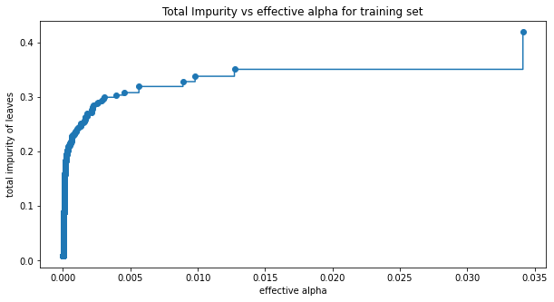

```python
fig, ax = plt.subplots(figsize=(10, 5))
ax.plot(ccp_alphas[:-1], impurities[:-1], marker="o", drawstyle="steps-post")
ax.set_xlabel("effective alpha")
ax.set_ylabel("total impurity of leaves")
ax.set_title("Total Impurity vs effective alpha for training set")
plt.show()
```

Next, we train a decision tree using effective alphas. The last value in ccp_alphas is the alpha value that prunes the whole tree, leaving the tree, clfs[-1], with one node.

```python
clfs = []
for ccp_alpha in ccp_alphas:
    clf = DecisionTreeClassifier(
        random_state=1, ccp_alpha=ccp_alpha, class_weight="balanced"
    )
    clf.fit(X_train, y_train)
    clfs.append(clf)
print(
    "Number of nodes in the last tree is: {} with ccp_alpha: {}".format(
        clfs[-1].tree_.node_count, ccp_alphas[-1]
    )
)
```

```
Number of nodes in the last tree is: 1 with ccp_alpha: 0.08117914389136943
```

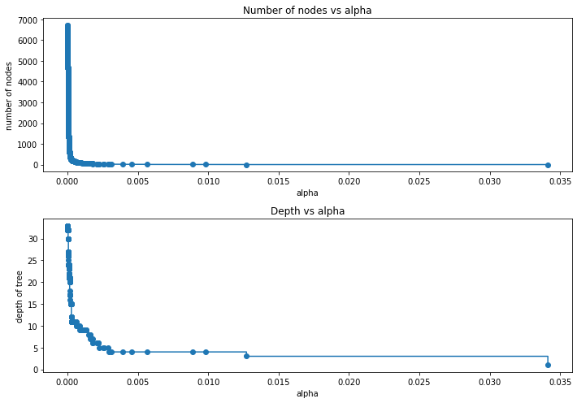

```python
clfs = clfs[:-1]
ccp_alphas = ccp_alphas[:-1]

node_counts = [clf.tree_.node_count for clf in clfs]
depth = [clf.tree_.max_depth for clf in clfs]
fig, ax = plt.subplots(2, 1, figsize=(10, 7))
ax[0].plot(ccp_alphas, node_counts, marker="o", drawstyle="steps-post")
ax[0].set_xlabel("alpha")
ax[0].set_ylabel("number of nodes")
ax[0].set_title("Number of nodes vs alpha")
ax[1].plot(ccp_alphas, depth, marker="o", drawstyle="steps-post")
ax[1].set_xlabel("alpha")
ax[1].set_ylabel("depth of tree")
ax[1].set_title("Depth vs alpha")
fig.tight_layout()
```

F1 Score vs alpha for training and testing sets

```python
f1_train = []
for clf in clfs:
    pred_train = clf.predict(X_train)
    values_train = f1_score(y_train, pred_train)
    f1_train.append(values_train)

f1_test = []
for clf in clfs:
    pred_test = clf.predict(X_test)
    values_test = f1_score(y_test, pred_test)
    f1_test.append(values_test)
```

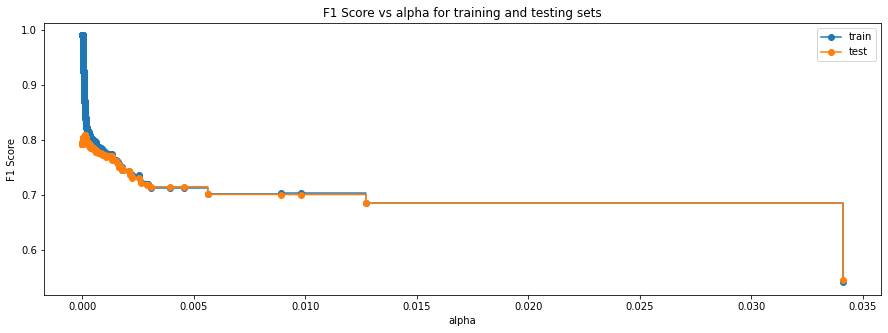

```python
fig, ax = plt.subplots(figsize=(15, 5))
ax.set_xlabel("alpha")
ax.set_ylabel("F1 Score")
ax.set_title("F1 Score vs alpha for training and testing sets")
ax.plot(ccp_alphas, f1_train, marker="o", label="train", drawstyle="steps-post")
ax.plot(ccp_alphas, f1_test, marker="o", label="test", drawstyle="steps-post")
ax.legend()
plt.show()
```

```python
index_best_model = np.argmax(f1_test)
best_model = clfs[index_best_model]
print(best_model)
```

```
DecisionTreeClassifier(ccp_alpha=0.0001226763315516701, class_weight='balanced',
                       random_state=1)
```

Checking performance on training set

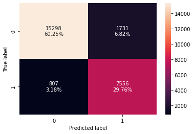

```python
confusion_matrix_sklearn(best_model, X_train, y_train)
```

```python
decision_tree_post_perf_train = model_performance_classification_sklearn(
    best_model, X_train, y_train
)
decision_tree_post_perf_train
```

|  | Accuracy | Recall | Precision | F1 |
| --- | --- | --- | --- | --- |
| 0 | 0.90005 | 0.90350 | 0.81361 | 0.85620 |

Checking performance on test set

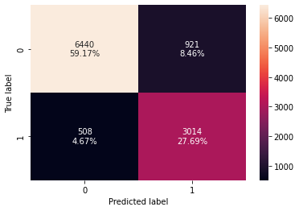

```python
## Complete the code to create confusion matrix for test data on best model
confusion_matrix_sklearn(best_model, X_test, y_test)
```

```python
decision_tree_post_test = model_performance_classification_sklearn(best_model, X_test, y_test)

decision_tree_post_test
```

|  | Accuracy | Recall | Precision | F1 |
| --- | --- | --- | --- | --- |
| 0 | 0.86869 | 0.85576 | 0.76595 | 0.80837 |

[figure not shown]

```python
plt.figure(figsize=(20, 10))

out = tree.plot_tree(
    best_model,
    feature_names=feature_names,
    filled=True,
    fontsize=9,
    node_ids=False,
    class_names=None,
)
for o in out:
    arrow = o.arrow_patch
    if arrow is not None:
        arrow.set_edgecolor("black")
        arrow.set_linewidth(1)
plt.show()
```

```python
# Text report showing the rules of a decision tree -

print(tree.export_text(best_model, feature_names=feature_names, show_weights=True))
```

```
|--- lead_time <= 151.50
|   |--- no_of_special_requests <= 0.50
|   |   |--- market_segment_type_Online <= 0.50
|   |   |   |--- lead_time <= 90.50
|   |   |   |   |--- no_of_weekend_nights <= 0.50
|   |   |   |   |   |--- avg_price_per_room <= 196.50
|   |   |   |   |   |   |--- market_segment_type_Offline <= 0.50
|   |   |   |   |   |   |   |--- lead_time <= 16.50
|   |   |   |   |   |   |   |   |--- avg_price_per_room <= 68.50
|   |   |   |   |   |   |   |   |   |--- weights: [207.26, 10.63] class: 0
|   |   |   |   |   |   |   |   |--- avg_price_per_room >  68.50
|   |   |   |   |   |   |   |   |   |--- arrival_date <= 29.50
|   |   |   |   |   |   |   |   |   |   |--- no_of_adults <= 1.50
|   |   |   |   |   |   |   |   |   |   |   |--- truncated branch of depth 2
|   |   |   |   |   |   |   |   |   |   |--- no_of_adults >  1.50
|   |   |   |   |   |   |   |   |   |   |   |--- truncated branch of depth 5
|   |   |   |   |   |   |   |   |   |--- arrival_date >  29.50
|   |   |   |   |   |   |   |   |   |   |--- weights: [2.24, 7.59] class: 1
|   |   |   |   |   |   |   |--- lead_time >  16.50
|   |   |   |   |   |   |   |   |--- avg_price_per_room <= 135.00
|   |   |   |   |   |   |   |   |   |--- arrival_month <= 11.50
|   |   |   |   |   |   |   |   |   |   |--- repeated_guest <= 0.50
|   |   |   |   |   |   |   |   |   |   |   |--- truncated branch of depth 4
|   |   |   |   |   |   |   |   |   |   |--- repeated_guest >  0.50
|   |   |   |   |   |   |   |   |   |   |   |--- weights: [11.18, 0.00] class: 0
|   |   |   |   |   |   |   |   |   |--- arrival_month >  11.50
|   |   |   |   |   |   |   |   |   |   |--- weights: [21.62, 0.00] class: 0
|   |   |   |   |   |   |   |   |--- avg_price_per_room >  135.00
|   |   |   |   |   |   |   |   |   |--- weights: [0.00, 12.14] class: 1
|   |   |   |   |   |   |--- market_segment_type_Offline >  0.50
|   |   |   |   |   |   |   |--- weights: [1199.59, 0.00] class: 0
|   |   |   |   |   |--- avg_price_per_room >  196.50
|   |   |   |   |   |   |--- weights: [0.75, 25.81] class: 1
|   |   |   |   |--- no_of_weekend_nights >  0.50
|   |   |   |   |   |--- lead_time <= 68.50
|   |   |   |   |   |   |--- arrival_month <= 9.50
|   |   |   |   |   |   |   |--- avg_price_per_room <= 63.29
|   |   |   |   |   |   |   |   |--- arrival_date <= 20.50
|   |   |   |   |   |   |   |   |   |--- type_of_meal_plan_Not Selected <= 0.50
|   |   |   |   |   |   |   |   |   |   |--- weights: [41.75, 0.00] class: 0
```

[output cut: 651 more lines]

```
|   |   |   |   |   |   |--- weights: [5.96, 4.55] class: 0
|   |--- avg_price_per_room >  100.04
|   |   |--- arrival_month <= 11.50
|   |   |   |--- no_of_special_requests <= 2.50
|   |   |   |   |--- weights: [0.00, 3200.19] class: 1
|   |   |   |--- no_of_special_requests >  2.50
|   |   |   |   |--- weights: [23.11, 0.00] class: 0
|   |   |--- arrival_month >  11.50
|   |   |   |--- no_of_special_requests <= 0.50
|   |   |   |   |--- weights: [35.04, 0.00] class: 0
|   |   |   |--- no_of_special_requests >  0.50
|   |   |   |   |--- arrival_date <= 24.50
|   |   |   |   |   |--- weights: [3.73, 0.00] class: 0
|   |   |   |   |--- arrival_date >  24.50
|   |   |   |   |   |--- weights: [3.73, 22.77] class: 1
```

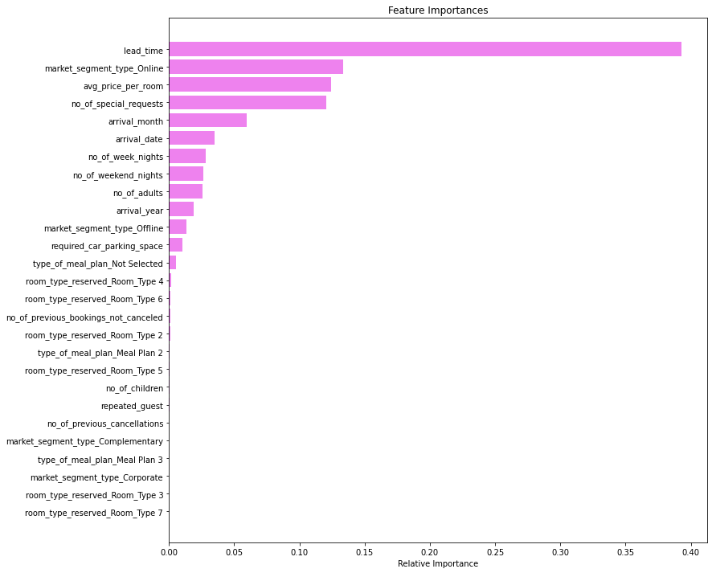

```python
importances = best_model.feature_importances_
indices = np.argsort(importances)

plt.figure(figsize=(12, 12))
plt.title("Feature Importances")
plt.barh(range(len(indices)), importances[indices], color="violet", align="center")
plt.yticks(range(len(indices)), [feature_names[i] for i in indices])
plt.xlabel("Relative Importance")
plt.show()
```

Comparing Decision Tree models

```python
# training performance comparison

models_train_comp_df = pd.concat(
    [
        decision_tree_post_perf_train.T,
        decision_tree_tune_perf_train.T,
        decision_tree_post_perf_train.T,
    ],
    axis=1,
)
models_train_comp_df.columns = [
    "Decision Tree sklearn",
    "Decision Tree (Pre-Pruning)",
    "Decision Tree (Post-Pruning)",
]
print("Training performance comparison:")
models_train_comp_df
```

```
Training performance comparison:
```

[output not shown]

```python
# Testing performance comparison

models_test_comp_df = pd.concat(
    [
        decision_tree_perf_test.T,
        decision_tree_tune_perf_test.T,
        decision_tree_post_test.T,
    ],
    axis=1,
)
models_test_comp_df.columns = [
    "Decision Tree sklearn",
    "Decision Tree (Pre-Pruning)",
    "Decision Tree (Post-Pruning)",
]
print("Testing performance comparison:")
models_test_comp_df
```

```
Testing performance comparison:
```

|  | Decision Tree sklearn | Decision Tree (Pre-Pruning) | Decision Tree (Post-Pruning) |
| --- | --- | --- | --- |
| Accuracy | 0.87108 | 0.87108 | 0.86869 |
| Recall | 0.81034 | 0.81034 | 0.85576 |
| Precision | 0.79521 | 0.79521 | 0.76595 |
| F1 | 0.80270 | 0.80270 | 0.80837 |

## Model Performance Comparison and Conclusions

Testing Performance Comparison:

Accuracy: All three models achieve similar accuracy on the testing set, with the Decision Tree sklearn and Decision Tree with Pre-Pruning models both achieving an accuracy of 0.87108, and the Decision Tree with Post-Pruning model achieving a slightly lower accuracy of 0.86869.

Recall: The Decision Tree sklearn and Decision Tree with Pre-Pruning models achieve the same recall of 0.81034, while the Decision Tree with Post-Pruning model achieves a slightly higher recall of 0.85576.

Precision: The Decision Tree sklearn and Decision Tree with Pre-Pruning models achieve the same precision of 0.79521, while the Decision Tree with Post-Pruning model achieves a slightly lower precision of 0.76595.

F1 Score: The F1 scores for all three models on the testing set are relatively similar, with the Decision Tree sklearn and Decision Tree with Pre-Pruning models both achieving an F1 score of 0.80270, and the Decision Tree with Post-Pruning model achieving a slightly higher F1 score of 0.8083.

In summary, the Decision Tree with Pre-Pruning shows superior performance in terms of accuracy, recall, precision, and F1 score on the training set, indicating potential overfitting. However, on the testing set, all three models perform similarly, with the Decision Tree with Post-Pruning demonstrating slightly better recall and F1 score. This suggests that post-pruning helps generalize the model better to unseen data by reducing overfitting.

## Actionable Insights and Recommendations

- What profitable policies for cancellations and refunds can the hotel adopt?
- What other recommedations would you suggest to the hotel?

To address cancellations and refunds effectively and maximize profitability, the hotel can adopt several policies and implement additional strategies:

Flexible cancellation policies: Offer flexible cancellation policies that provide guests with options to modify or cancel their bookings with minimal penalties. Implementing policies such as free cancellation within a certain timeframe (e.g., 24 hours before check-in) can attract more bookings while reducing the likelihood of cancellations closer to the arrival date.

Tiered pricing and non-refundable rates: Implement tiered pricing structures that offer discounted rates for non-refundable bookings. This encourages guests to commit to their reservations while providing an incentive for booking in advance. Non-refundable rates can help mitigate revenue loss from cancellations by securing guaranteed revenue for the hotel.

Partial deposits or prepayments: Require guests to pay a partial deposit or prepayment at the time of booking, especially for high-demand periods or special promotions. Collecting a portion of the payment upfront reduces the financial impact of last-minute cancellations and ensures a level of commitment from guests.

Waitlist management: Implement a waitlist management system to fill canceled rooms quickly. Notify guests on the waitlist of available rooms and offer them the opportunity to book at a discounted rate. This maximizes occupancy and minimizes revenue loss from cancellations by optimizing room utilization.

Dynamic pricing and revenue management: Utilize dynamic pricing and revenue management strategies to adjust room rates based on demand fluctuations and booking patterns. Implement automated pricing algorithms that optimize rates in real-time to maximize revenue and profitability while considering factors such as seasonality, occupancy levels, and competitor pricing.

Upselling and cross-Selling: Offer upselling and cross-selling opportunities to increase revenue per guest. Promote room upgrades, amenities, and add-on services during the booking process or at check-in to enhance the guest experience and generate additional revenue streams.

Customer relationship management (CRM): Implement a CRM system to track guest preferences, booking history, and behavior patterns. Leverage guest data to personalize marketing communications, tailor offers to individual preferences, and foster guest loyalty. Building strong relationships with repeat guests can lead to higher retention rates and increased revenue over time.

Cancellation insurance: Offer guests the option to purchase cancellation insurance at the time of booking. Cancellation insurance provides guests with peace of mind and coverage for unforeseen circumstances that may lead to cancellations. Partnering with reputable insurance providers can generate additional revenue for the hotel while minimizing financial risk.

Post-stay feedback and Reputation Management: Solicit feedback from guests post-stay to identify areas for improvement and address any concerns promptly. Monitor online reviews and respond proactively to guest feedback to maintain a positive reputation and attract future bookings. Positive reviews and ratings can influence booking decisions and drive revenue growth.

Cost optimization and operational efficiency: Continuously evaluate operational processes and identify opportunities to streamline operations and reduce costs. Implement efficiency measures such as energy-saving initiatives, waste reduction programs, and optimized staffing levels to improve profitability while maintaining service quality.

By implementing these policies and recommendations, the hotel can effectively manage cancellations and refunds, optimize revenue generation, and enhance overall profitability. Additionally, fostering a guest-centric approach and prioritizing customer satisfaction can contribute to long-term success and sustained business growth.